# Reproducible Research Assignment #1

Purpose: This assignment analyzes anonymous data from an activity monitoring device and computes various results including the mean and median of steps taken and provides several graphs of the data to help in understanding the behaviour.

### 1. Initialization

Set the working directory where the data file is located and source files are saved.

### 2. Loading And Pre-processing The Data

```r
activity <- read.csv("activity.csv")
```

### 3. Histogram Of Steps Taken Each Day

Compute the number of steps for each day where data is available and create the histogram using ggplot2

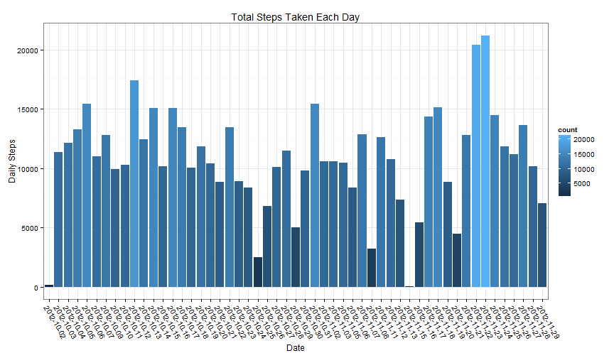

```r
library(ggplot2)
daily_steps <- aggregate(steps ~ date,activity,sum)

ggplot(daily_steps,aes(date)) + geom_histogram(aes(weight=steps,fill= ..count..),binwidth=1) + theme_bw() + xlab("Date") + ylab("Daily Steps") + ggtitle("Total Steps Taken Each Day") + theme(axis.text.x=element_text(angle = -60, hjust = 0))
```

### 4. Compute Mean and Median Of Steps Taken Each Day

```r
daily_mean   <- aggregate(steps ~ date, activity, mean)
daily_median <- aggregate(steps ~ date, activity, median)
```

Include the xtable package and then generate html style tables

```r
library(xtable)
table_mean <- xtable(daily_mean)
table_median <- xtable(daily_median)
```

### 5. Print Mean steps taken daily

```r
print(table_mean,type="html")
```

|  | date | steps |
| --- | --- | --- |
| 1 | 2012-10-02 | 0.44 |
| 2 | 2012-10-03 | 39.42 |
| 3 | 2012-10-04 | 42.07 |
| 4 | 2012-10-05 | 46.16 |
| 5 | 2012-10-06 | 53.54 |
| 6 | 2012-10-07 | 38.25 |
| 7 | 2012-10-09 | 44.48 |
| 8 | 2012-10-10 | 34.38 |
| 9 | 2012-10-11 | 35.78 |
| 10 | 2012-10-12 | 60.35 |
| 11 | 2012-10-13 | 43.15 |
| 12 | 2012-10-14 | 52.42 |
| 13 | 2012-10-15 | 35.20 |
| 14 | 2012-10-16 | 52.38 |
| 15 | 2012-10-17 | 46.71 |
| 16 | 2012-10-18 | 34.92 |
| 17 | 2012-10-19 | 41.07 |
| 18 | 2012-10-20 | 36.09 |
| 19 | 2012-10-21 | 30.63 |
| 20 | 2012-10-22 | 46.74 |
| 21 | 2012-10-23 | 30.97 |
| 22 | 2012-10-24 | 29.01 |
| 23 | 2012-10-25 | 8.65 |
| 24 | 2012-10-26 | 23.53 |
| 25 | 2012-10-27 | 35.14 |
| 26 | 2012-10-28 | 39.78 |
| 27 | 2012-10-29 | 17.42 |
| 28 | 2012-10-30 | 34.09 |
| 29 | 2012-10-31 | 53.52 |
| 30 | 2012-11-02 | 36.81 |
| 31 | 2012-11-03 | 36.70 |
| 32 | 2012-11-05 | 36.25 |
| 33 | 2012-11-06 | 28.94 |
| 34 | 2012-11-07 | 44.73 |
| 35 | 2012-11-08 | 11.18 |
| 36 | 2012-11-11 | 43.78 |
| 37 | 2012-11-12 | 37.38 |
| 38 | 2012-11-13 | 25.47 |
| 39 | 2012-11-15 | 0.14 |
| 40 | 2012-11-16 | 18.89 |
| 41 | 2012-11-17 | 49.79 |
| 42 | 2012-11-18 | 52.47 |
| 43 | 2012-11-19 | 30.70 |
| 44 | 2012-11-20 | 15.53 |
| 45 | 2012-11-21 | 44.40 |
| 46 | 2012-11-22 | 70.93 |
| 47 | 2012-11-23 | 73.59 |
| 48 | 2012-11-24 | 50.27 |
| 49 | 2012-11-25 | 41.09 |
| 50 | 2012-11-26 | 38.76 |
| 51 | 2012-11-27 | 47.38 |
| 52 | 2012-11-28 | 35.36 |
| 53 | 2012-11-29 | 24.47 |

### 6. Print Median steps taken daily

```r
print(table_median,type="html")
```

|  | date | steps |
| --- | --- | --- |
| 1 | 2012-10-02 | 0.00 |
| 2 | 2012-10-03 | 0.00 |
| 3 | 2012-10-04 | 0.00 |
| 4 | 2012-10-05 | 0.00 |
| 5 | 2012-10-06 | 0.00 |
| 6 | 2012-10-07 | 0.00 |
| 7 | 2012-10-09 | 0.00 |
| 8 | 2012-10-10 | 0.00 |
| 9 | 2012-10-11 | 0.00 |
| 10 | 2012-10-12 | 0.00 |
| 11 | 2012-10-13 | 0.00 |
| 12 | 2012-10-14 | 0.00 |
| 13 | 2012-10-15 | 0.00 |
| 14 | 2012-10-16 | 0.00 |
| 15 | 2012-10-17 | 0.00 |
| 16 | 2012-10-18 | 0.00 |
| 17 | 2012-10-19 | 0.00 |
| 18 | 2012-10-20 | 0.00 |
| 19 | 2012-10-21 | 0.00 |
| 20 | 2012-10-22 | 0.00 |
| 21 | 2012-10-23 | 0.00 |
| 22 | 2012-10-24 | 0.00 |
| 23 | 2012-10-25 | 0.00 |
| 24 | 2012-10-26 | 0.00 |
| 25 | 2012-10-27 | 0.00 |
| 26 | 2012-10-28 | 0.00 |
| 27 | 2012-10-29 | 0.00 |
| 28 | 2012-10-30 | 0.00 |
| 29 | 2012-10-31 | 0.00 |
| 30 | 2012-11-02 | 0.00 |
| 31 | 2012-11-03 | 0.00 |
| 32 | 2012-11-05 | 0.00 |
| 33 | 2012-11-06 | 0.00 |
| 34 | 2012-11-07 | 0.00 |
| 35 | 2012-11-08 | 0.00 |
| 36 | 2012-11-11 | 0.00 |
| 37 | 2012-11-12 | 0.00 |
| 38 | 2012-11-13 | 0.00 |
| 39 | 2012-11-15 | 0.00 |
| 40 | 2012-11-16 | 0.00 |
| 41 | 2012-11-17 | 0.00 |
| 42 | 2012-11-18 | 0.00 |
| 43 | 2012-11-19 | 0.00 |
| 44 | 2012-11-20 | 0.00 |
| 45 | 2012-11-21 | 0.00 |
| 46 | 2012-11-22 | 0.00 |
| 47 | 2012-11-23 | 0.00 |
| 48 | 2012-11-24 | 0.00 |
| 49 | 2012-11-25 | 0.00 |
| 50 | 2012-11-26 | 0.00 |
| 51 | 2012-11-27 | 0.00 |
| 52 | 2012-11-28 | 0.00 |
| 53 | 2012-11-29 | 0.00 |

### 7. Average Daily Activity Pattern

7a. Compute the average number of steps taken in each five minute interval

```r
iave <- aggregate(steps ~ interval, activity, mean)
```

7b. Create a time series plot of the average steps taken versus the interval

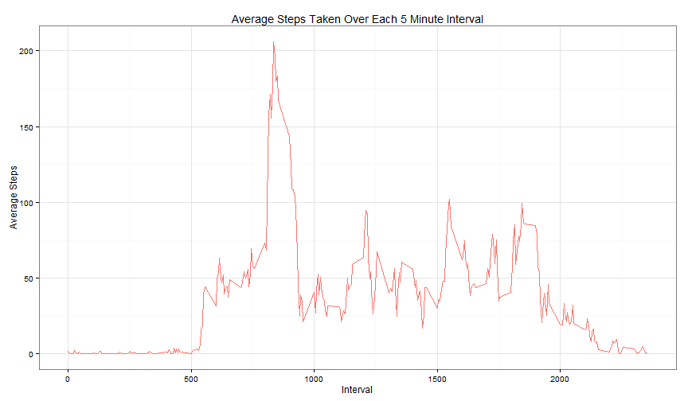

```r
ggplot(iave,aes(interval,steps)) + geom_line(aes(colour="blue")) + ylab("Average Steps") + xlab("Interval") + ggtitle("Average Steps Taken Over Each 5 Minute Interval") + theme_bw() + theme(legend.position="none")
```

### 8. Compute Five Minute Interval With the Maximum Number Of Average Steps

```r
max_row <- which.max(iave$steps)
max_interval <- iave$interval[max_row]
max_steps <- iave$steps[max_row]
```

### 9. Maximum average steps of 206.1698 occurs at Max Interval 835

### 10. Replacing missing values

#### 10a. Compute the total number of missing values (NA)

```r
missing_values <- sum(is.na(activity$steps))
```

#### 10b. There are 2304 missing values in the data

#### 10c. Replace missing values

We will now set the missing values with the mean value for that interval and create a new data set (call it 'Modified Data')

```r
imputed_activity <- activity
fn <- function(steps,interval) ifelse(is.na(steps),iave$steps[iave$interval==interval],steps)
imputed_activity$steps <- apply(activity[,c('steps','interval')],1,function(y) fn(y['steps'],y['interval']) )
```

### 11. Histogram Of Steps Taken Each Day Based On Modified Data

Compute the number of steps for each day from the inputed data and create the histogram

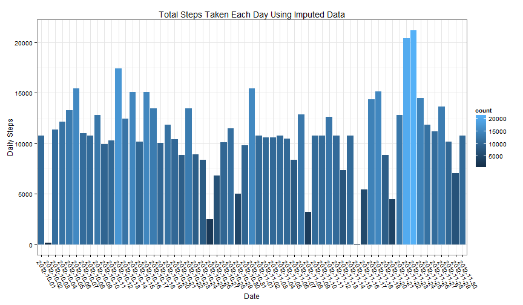

```r
imputed_steps <- aggregate(steps ~ date,imputed_activity,sum)

ggplot(imputed_steps,aes(date)) + geom_histogram(aes(weight=steps,fill= ..count..),binwidth=1) + theme_bw() + xlab("Date") + ylab("Daily Steps") + ggtitle("Total Steps Taken Each Day Using Imputed Data") + theme(axis.text.x=element_text(angle = -60, hjust = 0))
```

### 12. Compute Mean and Median Of Steps Taken Each Day Using The Modified Data

```r
imputed_daily_mean   <- aggregate(steps ~ date, imputed_activity, mean)
imputed_daily_median <- aggregate(steps ~ date, imputed_activity, median)
```

```r
imputed_table_mean <- xtable(imputed_daily_mean)
imputed_table_median <- xtable(imputed_daily_median)
```

### 13. Print Mean steps taken daily using Modified Data

```r
print(imputed_table_mean,type="html")
```

|  | date | steps |
| --- | --- | --- |
| 1 | 2012-10-01 | 37.38 |
| 2 | 2012-10-02 | 0.44 |
| 3 | 2012-10-03 | 39.42 |
| 4 | 2012-10-04 | 42.07 |
| 5 | 2012-10-05 | 46.16 |
| 6 | 2012-10-06 | 53.54 |
| 7 | 2012-10-07 | 38.25 |
| 8 | 2012-10-08 | 37.38 |
| 9 | 2012-10-09 | 44.48 |
| 10 | 2012-10-10 | 34.38 |
| 11 | 2012-10-11 | 35.78 |
| 12 | 2012-10-12 | 60.35 |
| 13 | 2012-10-13 | 43.15 |
| 14 | 2012-10-14 | 52.42 |
| 15 | 2012-10-15 | 35.20 |
| 16 | 2012-10-16 | 52.38 |
| 17 | 2012-10-17 | 46.71 |
| 18 | 2012-10-18 | 34.92 |
| 19 | 2012-10-19 | 41.07 |
| 20 | 2012-10-20 | 36.09 |
| 21 | 2012-10-21 | 30.63 |
| 22 | 2012-10-22 | 46.74 |
| 23 | 2012-10-23 | 30.97 |
| 24 | 2012-10-24 | 29.01 |
| 25 | 2012-10-25 | 8.65 |
| 26 | 2012-10-26 | 23.53 |
| 27 | 2012-10-27 | 35.14 |
| 28 | 2012-10-28 | 39.78 |
| 29 | 2012-10-29 | 17.42 |
| 30 | 2012-10-30 | 34.09 |
| 31 | 2012-10-31 | 53.52 |
| 32 | 2012-11-01 | 37.38 |
| 33 | 2012-11-02 | 36.81 |
| 34 | 2012-11-03 | 36.70 |
| 35 | 2012-11-04 | 37.38 |
| 36 | 2012-11-05 | 36.25 |
| 37 | 2012-11-06 | 28.94 |
| 38 | 2012-11-07 | 44.73 |
| 39 | 2012-11-08 | 11.18 |
| 40 | 2012-11-09 | 37.38 |
| 41 | 2012-11-10 | 37.38 |
| 42 | 2012-11-11 | 43.78 |
| 43 | 2012-11-12 | 37.38 |
| 44 | 2012-11-13 | 25.47 |
| 45 | 2012-11-14 | 37.38 |
| 46 | 2012-11-15 | 0.14 |
| 47 | 2012-11-16 | 18.89 |
| 48 | 2012-11-17 | 49.79 |
| 49 | 2012-11-18 | 52.47 |
| 50 | 2012-11-19 | 30.70 |
| 51 | 2012-11-20 | 15.53 |
| 52 | 2012-11-21 | 44.40 |
| 53 | 2012-11-22 | 70.93 |
| 54 | 2012-11-23 | 73.59 |
| 55 | 2012-11-24 | 50.27 |
| 56 | 2012-11-25 | 41.09 |
| 57 | 2012-11-26 | 38.76 |
| 58 | 2012-11-27 | 47.38 |
| 59 | 2012-11-28 | 35.36 |
| 60 | 2012-11-29 | 24.47 |
| 61 | 2012-11-30 | 37.38 |

### 14. Print Median steps taken daily using Modified Data

```r
print(imputed_table_median,type="html")
```

|  | date | steps |
| --- | --- | --- |
| 1 | 2012-10-01 | 34.11 |
| 2 | 2012-10-02 | 0.00 |
| 3 | 2012-10-03 | 0.00 |
| 4 | 2012-10-04 | 0.00 |
| 5 | 2012-10-05 | 0.00 |
| 6 | 2012-10-06 | 0.00 |
| 7 | 2012-10-07 | 0.00 |
| 8 | 2012-10-08 | 34.11 |
| 9 | 2012-10-09 | 0.00 |
| 10 | 2012-10-10 | 0.00 |
| 11 | 2012-10-11 | 0.00 |
| 12 | 2012-10-12 | 0.00 |
| 13 | 2012-10-13 | 0.00 |
| 14 | 2012-10-14 | 0.00 |
| 15 | 2012-10-15 | 0.00 |
| 16 | 2012-10-16 | 0.00 |
| 17 | 2012-10-17 | 0.00 |
| 18 | 2012-10-18 | 0.00 |
| 19 | 2012-10-19 | 0.00 |
| 20 | 2012-10-20 | 0.00 |
| 21 | 2012-10-21 | 0.00 |
| 22 | 2012-10-22 | 0.00 |
| 23 | 2012-10-23 | 0.00 |
| 24 | 2012-10-24 | 0.00 |
| 25 | 2012-10-25 | 0.00 |
| 26 | 2012-10-26 | 0.00 |
| 27 | 2012-10-27 | 0.00 |
| 28 | 2012-10-28 | 0.00 |
| 29 | 2012-10-29 | 0.00 |
| 30 | 2012-10-30 | 0.00 |
| 31 | 2012-10-31 | 0.00 |
| 32 | 2012-11-01 | 34.11 |
| 33 | 2012-11-02 | 0.00 |
| 34 | 2012-11-03 | 0.00 |
| 35 | 2012-11-04 | 34.11 |
| 36 | 2012-11-05 | 0.00 |
| 37 | 2012-11-06 | 0.00 |
| 38 | 2012-11-07 | 0.00 |
| 39 | 2012-11-08 | 0.00 |
| 40 | 2012-11-09 | 34.11 |
| 41 | 2012-11-10 | 34.11 |
| 42 | 2012-11-11 | 0.00 |
| 43 | 2012-11-12 | 0.00 |
| 44 | 2012-11-13 | 0.00 |
| 45 | 2012-11-14 | 34.11 |
| 46 | 2012-11-15 | 0.00 |
| 47 | 2012-11-16 | 0.00 |
| 48 | 2012-11-17 | 0.00 |
| 49 | 2012-11-18 | 0.00 |
| 50 | 2012-11-19 | 0.00 |
| 51 | 2012-11-20 | 0.00 |
| 52 | 2012-11-21 | 0.00 |
| 53 | 2012-11-22 | 0.00 |
| 54 | 2012-11-23 | 0.00 |
| 55 | 2012-11-24 | 0.00 |
| 56 | 2012-11-25 | 0.00 |
| 57 | 2012-11-26 | 0.00 |
| 58 | 2012-11-27 | 0.00 |
| 59 | 2012-11-28 | 0.00 |
| 60 | 2012-11-29 | 0.00 |
| 61 | 2012-11-30 | 34.11 |

### 15. Compute Weekdays and Weekends

Add a factor to the inputed data frame that describes whether the date is a weekday or weekend

```r
dowfunc <- function(d) ifelse(is.na(match(weekdays(d),c("Saturday","Sunday"))),"weekday","weekend")
imputed_activity$dow <- factor(apply(imputed_activity[c('date')],1,function(y) dowfunc(as.Date(y['date']))))
```

Create a time series plot of the average steps taken versus the interval on a weekday and a time series plot of the average steps over the interval on the weekend.

Tried 2 versions of a lattice graph using xyplot and ggplot but was unable to determine why the graph was messy and had extra lines in it.

Resorted to the last version of graphs which are separate but seem to accurately capture the data for the weekend.

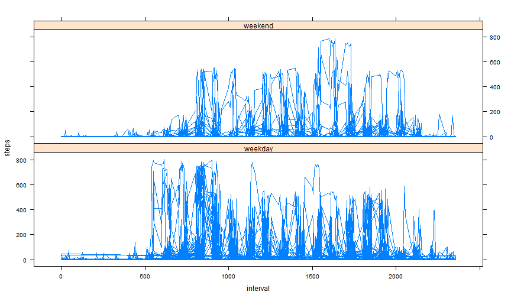

```r
weekend_activity <- imputed_activity[imputed_activity$dow=="weekend",]
weekday_activity <- imputed_activity[imputed_activity$dow=="weekday",]
weekend_ave <- aggregate(steps ~ interval, weekend_activity, mean)
weekday_ave <- aggregate(steps ~ interval, weekday_activity, mean)

library(lattice)
xyplot(steps ~ interval| dow,data=imputed_activity,layout=c(1,2),type="l")
```

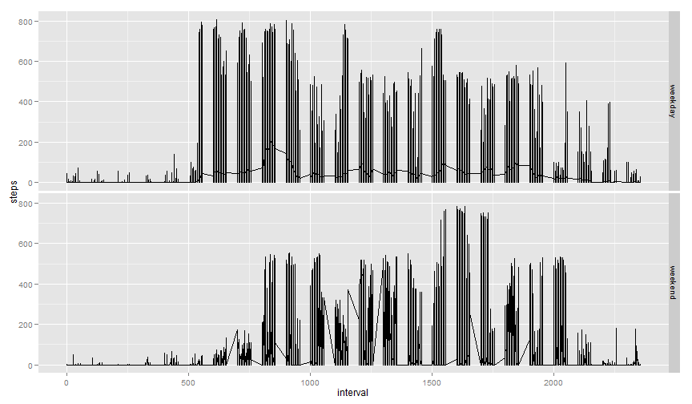

```r
ggplot(imputed_activity, aes(x=interval, y=steps, group=dow)) + geom_line() + facet_grid( dow ~ .)
```

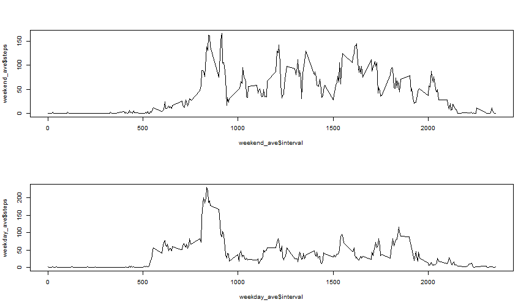

```r
layout(matrix(c(1,1,2,2), 2, 2, byrow = TRUE))
plot(weekend_ave$interval,weekend_ave$steps,type="l")
plot(weekday_ave$interval,weekday_ave$steps,type="l")
```